# Regulocracia Federal Brasileira

Leandro Alves Carneiro

04/12/2020

## A Regulocracia Federal Brasileira. O que é?

O termo “regulocracia” é comumente utilizado para se referir à burocracia (no sentido weberiano) das Agências reguladoras. Neste trabalho foram utilizadas como referência as 11 autarquias listadas no art. 2º da Lei nº 13.848/2019, nova Lei das Agências Reguladoras, disponível em http://www.planalto.gov.br/ccivil_03/_Ato2019-2022/2019/Lei/L13848.htm:

- Agência Nacional de Águas – ANA;
- Agência Nacional de Aviação Civil – ANAC;
- Agência Nacional de Energia Elétrica – ANEEL;
- Agência Nacional de Mineração – ANM;
- Agência Nacional de Saúde Suplementar – ANS;
- Agência Nacional de Telecomunicações – Anatel;
- Agência Nacional de Transportes Aquaviários – ANTAQ;
- Agência Nacional de Transportes Terrestres – ANTT;
- Agência Nacional de Vigilância Sanitária – Anvisa;
- Agência Nacional do Cinema – Ancine;
- Agência Nacional do Petróleo, Gás Natural e Biocombustíveis – ANP.

## Metodologia

Para obtenção dos dados empíricos utilizados neste trabalho, foram utilizadas bases de dados do Portal da Transparência (http://www.portaldatransparencia.gov.br/download-de-dados/servidores) referentes aos servidores civis empregados pela União no mês de janeiro de 2020. Após a extração, os dados foram importados para o R, que foi o software utilizado para manipulação.

A base de dados utilizada fornece diversas informações sobre os servidores, como o nome completo e seus órgãos de lotação e de exercício. Essas duas últimas informações foram essenciais para o presente trabalho, pois com elas pode-se saber se as agências reguladoras têm burocracias próprias, os seja, servidores que têm vínculos permanentes com a instituição.

Pode-se supor também que esses servidores têm um maior grau de comprometimento com a agência do que servidores cedidos, o que seria uma aproximação da variável “commitment”, citada por Brynard (2009) como uma importante variável na capacidade de um agente estatal implementar políticas públicas. Além disso, pode-se saber se servidores das agências reguladoras estão sendo cedidos a outros órgãos, movimento que, se realizado em excesso, pode também minar a capacidade de a agência executar seu trabalho. Ressalta-se que, para este trabalho, o interesse principal era no órgão de exercício, pois esse campo mostra os servidores que efetivamente atuam nas agências.

Vale mencionar também que havia muitos registros duplicados, uma vez que um servidor que exerce um cargo comissionado aparecia duas vezes: uma primeira vez para o seu cargo efetivo e uma segunda vez para o cargo comissionado que ocupa.

Com os dados de lotação e exercício, foi construída uma matriz de incidência, ou seja, nas linhas foram colocadas as informações dos órgãos de origem (lotação) e nas colunas as informações dos órgãos de exercício. Com isso foi possível saber quantos servidores de determinada agência são provenientes de sua burocracia própria e quantos proveem de outros órgãos e ainda quais são esses outros órgãos. Por esta razão, a matriz não é 11x11, com dados somente das agências, mas 129 x 129. Ou seja, além das 11 agências, existem ainda 118 órgãos que cedem ou recebem servidores provenientes das agências reguladoras.

## Análise dos resultados empíricos

### Tamanho das agências:

Uma das primeiras informações para se caracterizar a burocracia das agências é o tamanho seu corpo de servidores, o que é sintetizado no gráfico abaixo:

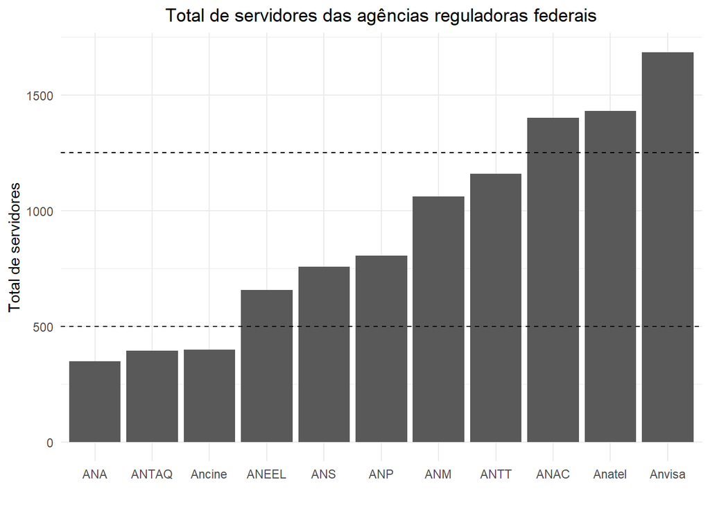

De maneira geral, quanto ao tamanho, percebe-se que existem basicamente três grupos de agências, as grandes, compostas por Anvisa, Anatel e ANAC, as médias, compostas por ANTT, ANM, ANP, ANS e ANEEL e as pequenas, compostas por Ancine, ANTAQ e ANA. Essa classificação foi feita tendo como pontos de corte os valores de 500 servidores e 1250 servidores, mas outros valores poderiam ser escolhidos, o que não invalidada a percepção da grande heterogeneidade desses órgãos.

O tamanho da agência é uma variável importante, pois pode, em caso de número reduzido de servidores, ser um gargalo na qualidade regulatória da agência, bem como reflete a capacidade de fiscalização do órgão, cujas necessidades variam bastante de acordo com a do setor regulado.

Uma avaliação interessante seria separar os servidores entre aqueles ligados à atividade de fiscalização e aqueles ligados à regulação econômica. Isso traria uma noção de descentralização das atividades, bem como uma possível avaliação dos burocratas de nível de rua, já que a atividade de fiscalização tem relação direta com os entes regulados e, em algumas situações, com a própria população.

### Índice de captura da regulocracia pelo governo

De modo a se avaliar de maneira mais objetiva a possibilidade de captura de uma regulocracia, foi criado um índice que avalia essa captura por parte de um dos stakeholders mais importantes, o governo. Vale lembrar que as agências reguladoras foram criadas para ser autarquias autônomas em relação ao governo, com orçamentos próprios, mandatos estáveis de seus dirigentes, dentre outras características que tinham como objetivo dar maior credibilidade, tecnicidade e estabilidade nas decisões.

O presente índice procura medir o quanto a burocracia das agências reguladoras é composta por servidores próprios ou advindos do governo. O índice incorpora também a quantidade de servidores que foram retirados das agências, ou seja, que estão em exercício em outros órgãos, já que esse pode ser também um mecanismo para o “esvaziamento” da agência.

O cálculo do índice é feito a partir da média de dois indicadores, um referente aos servidores cedidos a outros órgãos e outro indicador referente aos servidores em exercício provenientes de outros órgãos.

As fórmulas ficam assim:

- I_cedidos = número de servidores cedidos / número de servidores lotados.
- I_exercício = número de servidores de outros órgãos em exercício / número de servires em exercício
- I_captura_gov = (I_cedidos + I_exercício) / 2

Portanto, para o cálculo do índice, são utilizadas 4 variáveis:

- número de servidores cedidos;
- número de servidores de outros órgãos em exercício;
- número de servidores lotados;
- número de servires em exercício.

O gráfico abaixo ilustra esse indicador:

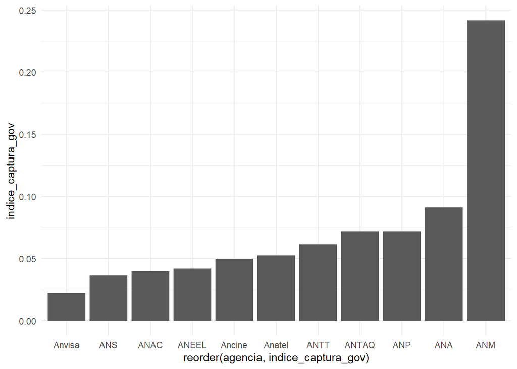

Como se percebe a ANM deve um resultado preocupante, uma vez que a agência tem muitos servidores cedidos a outros órgãos, bem como tem muitos servidores em exercício que não são parte de sua burocracia própria. Esse fato reveste-se ainda de mais gravidade frente aos acidentes envolvendo represas de rejeitos de mineração nas cidades de Brumadinho e Mariana, trazendo questionamentos quanto à capacidade da agência de fiscalizar o setor.

## Cálculo do Alfa de Cronbach

Para se verificar a confiabilidade do indicador, fez-se o cálculo do Alfa de Cronbach a partir das variáveis mencionadas acima. Para isso, foi utilizado o pacote “psych” e sua função “alpha” aplicada aos valores das variáveis mencionadas acima.

O resultado foi um Alfa de Cronbach com valor de 0.831663. Portanto, um valor razoável para utilização.